# wineQualityReds

```
## wines$quality: 3
##    Min. 1st Qu.  Median    Mean 3rd Qu.    Max.
##   8.400   9.725   9.925   9.955  10.580  11.000
## --------------------------------------------------------
## wines$quality: 4
##    Min. 1st Qu.  Median    Mean 3rd Qu.    Max.
##    9.00    9.60   10.00   10.27   11.00   13.10
## --------------------------------------------------------
## wines$quality: 5
##    Min. 1st Qu.  Median    Mean 3rd Qu.    Max.
##     8.5     9.4     9.7     9.9    10.2    14.9
## --------------------------------------------------------
## wines$quality: 6
##    Min. 1st Qu.  Median    Mean 3rd Qu.    Max.
##    8.40    9.80   10.50   10.63   11.30   14.00
## --------------------------------------------------------
## wines$quality: 7
##    Min. 1st Qu.  Median    Mean 3rd Qu.    Max.
##    9.20   10.80   11.50   11.47   12.10   14.00
## --------------------------------------------------------
## wines$quality: 8
##    Min. 1st Qu.  Median    Mean 3rd Qu.    Max.
##    9.80   11.32   12.15   12.09   12.88   14.00
```

highest quality wines (8) have the highest median and the lowest quality wines which are labeled at 3 have the lowest amount of alcohol, except for the ones that are scored at 5.

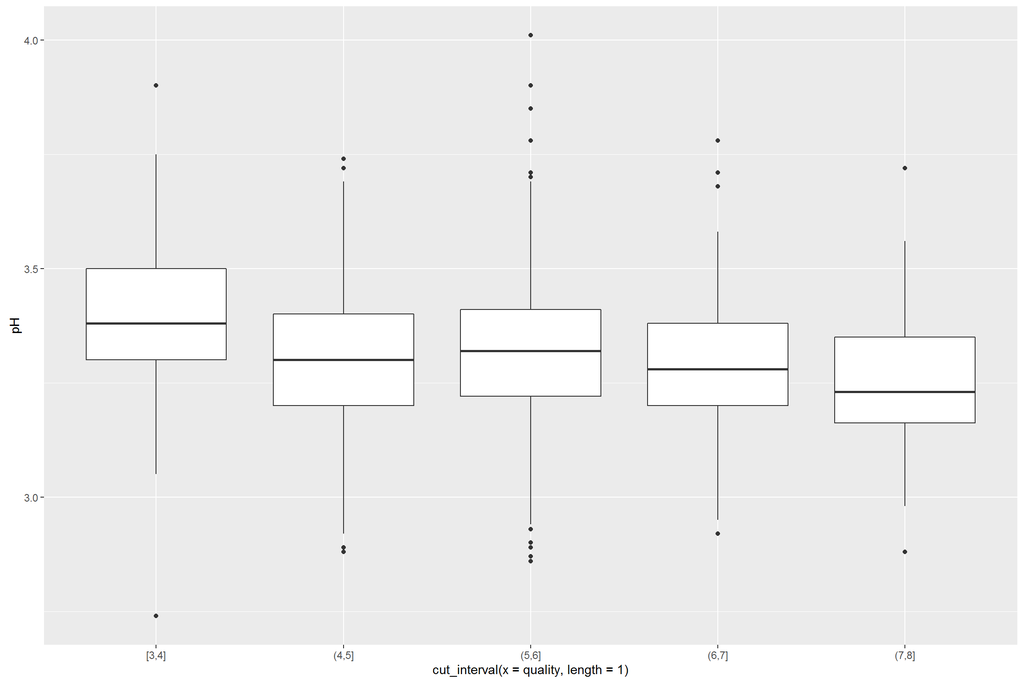

```
## wines$quality: 3
##    Min. 1st Qu.  Median    Mean 3rd Qu.    Max.
##   3.160   3.312   3.390   3.398   3.495   3.630
## --------------------------------------------------------
## wines$quality: 4
##    Min. 1st Qu.  Median    Mean 3rd Qu.    Max.
##   2.740   3.300   3.370   3.382   3.500   3.900
## --------------------------------------------------------
## wines$quality: 5
##    Min. 1st Qu.  Median    Mean 3rd Qu.    Max.
##   2.880   3.200   3.300   3.305   3.400   3.740
## --------------------------------------------------------
## wines$quality: 6
##    Min. 1st Qu.  Median    Mean 3rd Qu.    Max.
##   2.860   3.220   3.320   3.318   3.410   4.010
## --------------------------------------------------------
## wines$quality: 7
##    Min. 1st Qu.  Median    Mean 3rd Qu.    Max.
##   2.920   3.200   3.280   3.291   3.380   3.780
## --------------------------------------------------------
## wines$quality: 8
##    Min. 1st Qu.  Median    Mean 3rd Qu.    Max.
##   2.880   3.162   3.230   3.267   3.350   3.720
```

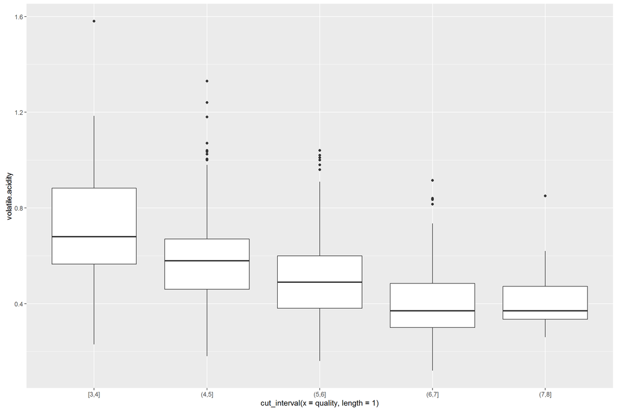

```
## wines$quality: 3
##    Min. 1st Qu.  Median    Mean 3rd Qu.    Max.
##  0.4400  0.6475  0.8450  0.8845  1.0100  1.5800
## --------------------------------------------------------
## wines$quality: 4
##    Min. 1st Qu.  Median    Mean 3rd Qu.    Max.
##   0.230   0.530   0.670   0.694   0.870   1.130
## --------------------------------------------------------
## wines$quality: 5
##    Min. 1st Qu.  Median    Mean 3rd Qu.    Max.
##   0.180   0.460   0.580   0.577   0.670   1.330
## --------------------------------------------------------
## wines$quality: 6
##    Min. 1st Qu.  Median    Mean 3rd Qu.    Max.
##  0.1600  0.3800  0.4900  0.4975  0.6000  1.0400
## --------------------------------------------------------
## wines$quality: 7
##    Min. 1st Qu.  Median    Mean 3rd Qu.    Max.
##  0.1200  0.3000  0.3700  0.4039  0.4850  0.9150
## --------------------------------------------------------
## wines$quality: 8
##    Min. 1st Qu.  Median    Mean 3rd Qu.    Max.
##  0.2600  0.3350  0.3700  0.4233  0.4725  0.8500
```

I see a relatively stronger corrolation between volatile acidity and quality(a negative one)

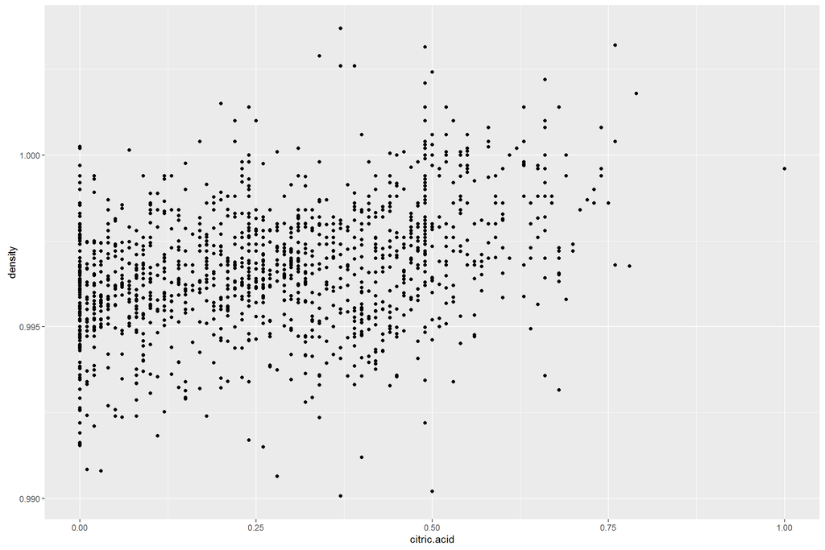

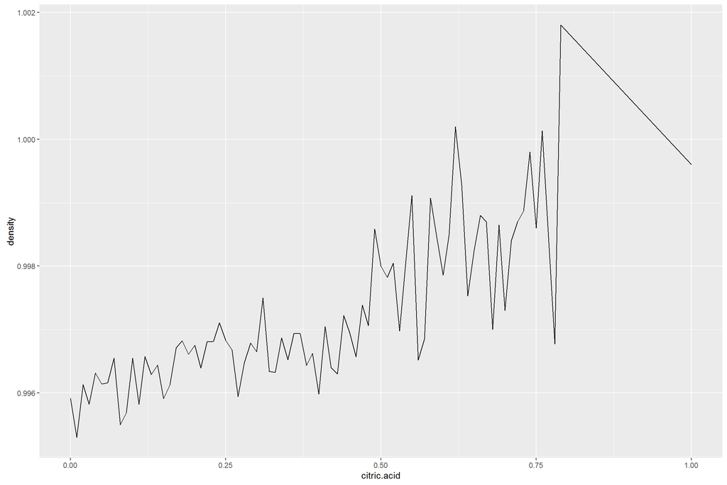

there seem to be positive corrolation between the two vairables citric acid and density. But they corrolations with quality seem to be opposite to one an other.

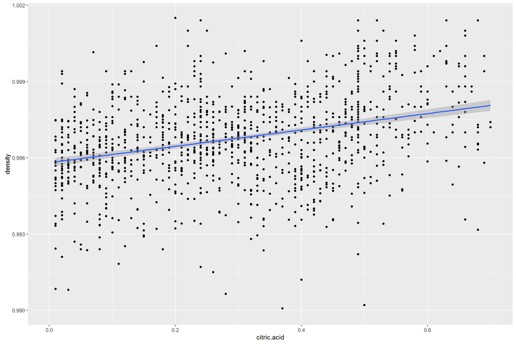

the relationship between citric.acid and density seem to be linear but it’s week and datapoints are very dispersed (there is a big variation)

```
##
## Calls:
## m1: lm(formula = density ~ citric.acid, data = subset(wines, citric.acid >
##     0 & citric.acid <= quantile(wines$citric.acid, 0.999)))
##
## =============================
##   (Intercept)      0.996***
##                   (0.000)
##   citric.acid      0.004***
##                   (0.000)
## -----------------------------
##   R-squared            0.1
##   adj. R-squared       0.1
##   sigma                0.0
##   F                  210.8
##   p                    0.0
##   Log-likelihood    7229.2
##   Deviance             0.0
##   AIC             -14452.3
##   BIC             -14436.5
##   N                 1465
## =============================
```

the model trained based on citric.acid to explain density, explains only 10% of variance which is negligble.

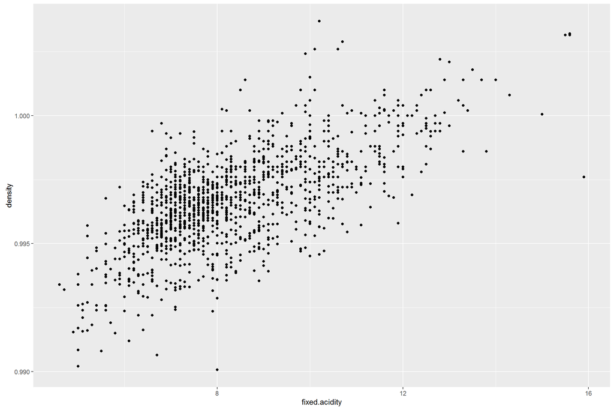

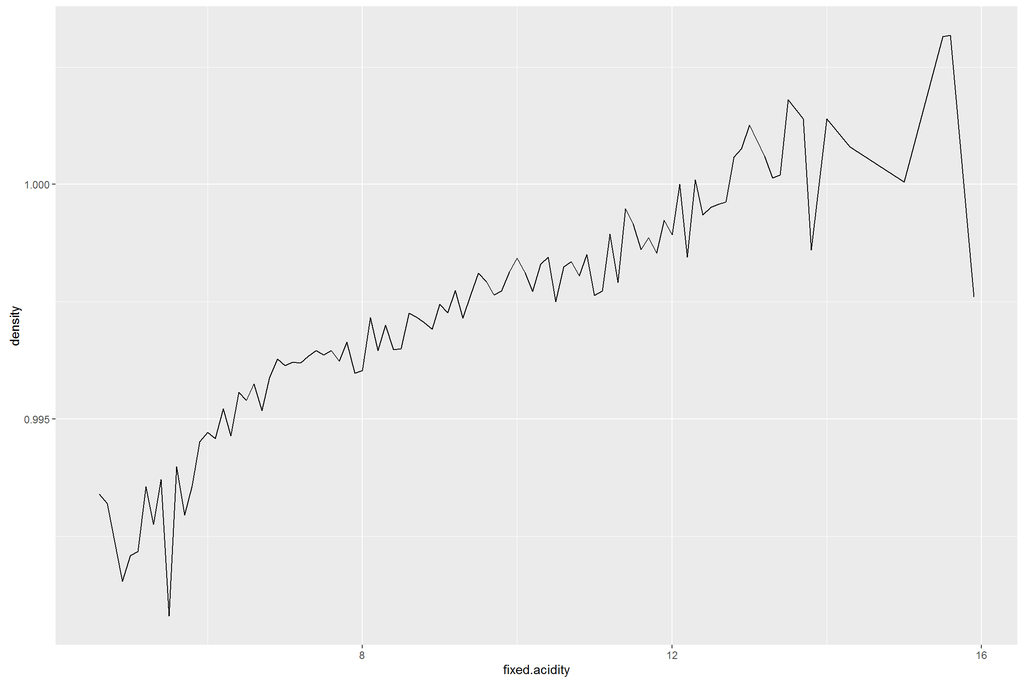

there is a corrolation between density and fixed.acidity. the higher the fixed.acidity, the higher the density.

```
##
## Calls:
## m2: lm(formula = quality ~ alcohol, data = subset(wines, alcohol >
##     0 & alcohol <= quantile(wines$alcohol, 0.999)))
##
## =============================
##   (Intercept)      1.818***
##                   (0.175)
##   alcohol          0.366***
##                   (0.017)
## -----------------------------
##   R-squared            0.2
##   adj. R-squared       0.2
##   sigma                0.7
##   F                  480.4
##   p                    0.0
##   Log-likelihood   -1715.4
##   Deviance           800.7
##   AIC               3436.8
##   BIC               3452.9
##   N                 1598
## =============================
```

despite corrolation of 0.47 between alcohol and quality, the model only explains 20% of variance of quality

```
##
## Calls:
## m3: lm(formula = quality ~ volatile.acidity, data = wines)
##
## ===============================
##   (Intercept)        6.566***
##                     (0.058)
##   volatile.acidity  -1.761***
##                     (0.104)
## -------------------------------
##   R-squared              0.2
##   adj. R-squared         0.2
##   sigma                  0.7
##   F                    287.4
##   p                      0.0
##   Log-likelihood     -1794.3
##   Deviance             883.2
##   AIC                 3594.6
##   BIC                 3610.8
##   N                   1599
## ===============================
```

only 20% of variance explained here. Perhaps I should add more features to the model in the next part.

# Bivariate Analysis

## Talk about some of the relationships you observed in this part of the investigation. How did the feature(s) of interest vary with other features in the dataset?

There is a moderate corrolation between quality and volatile.acidity. There is a stronger corrolation between quality and alcohol and a weaker one with citric.acid and sulphates and density.

There are, as one would expect, stronger corrolations between features that are related such as fixed.acidity and pH (pH is a measurement of acidity).

wines with higher amount of citric acid, alcohol and sulphates are likelier to have a higher quality. and the corrolation with volatile.acidity seem to be negative.

most wines have quality of 5 or 6 (80-90%).

the variation of all features is large and corrolations except for features which are basically related by nature such as acidity and pH, are week. The scatter plots also seem to be really scatterd.

wines with higher acid citric seem to have a higher density.

using R2 to explain variance in quality based on one feature does not seem to give a good result. In next section I will use more than one feature and see if there is any improvements.

## Did you observe any interesting relationships between the other features (not the main feature(s) of interest)?

there is a corrolation between free.sulfur.dioxide and total.sulfur.dioxide and it is understandable because one is subset of the other. also between acid.citric and density. there is even a stronger one between density and fixed acidity.

## What was the strongest relationship you found?

the strongest relationship is between fixed.acidity and pH. the higher the fixed.acidity, the lower the pH. There is also a strong corrolation between density and fixed.acidity. there are not very strong relation between any of them and quality.

# Multivariate Plots Section:

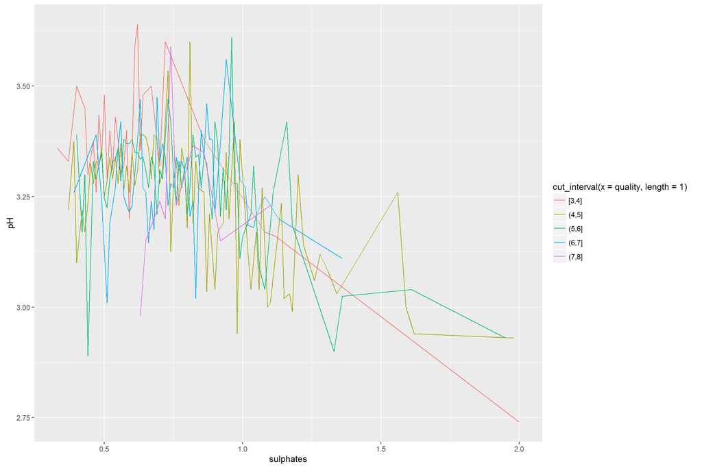

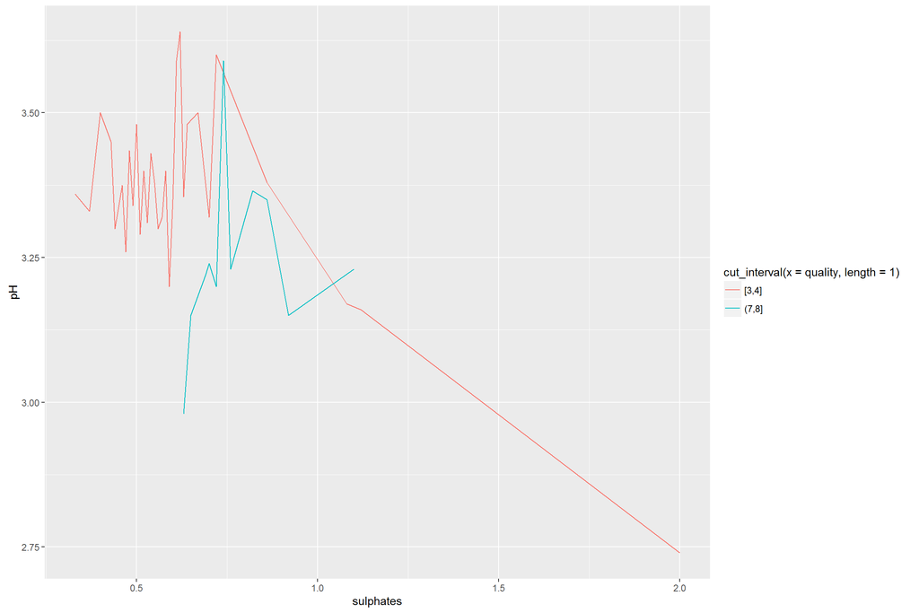

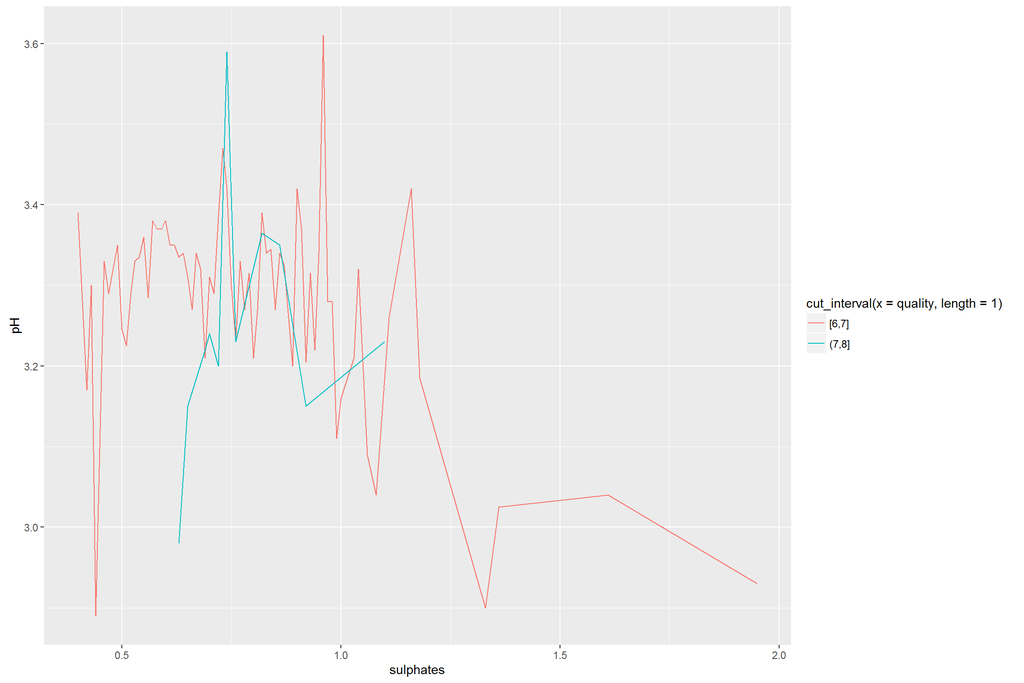

I did the second plot with only the top and lowest quality to make the distinction more clearly. The first plot is for all different qualities. It seems that comparing between the lowest quality and the higest, for the same amount of sulfate the wines have lower pH.

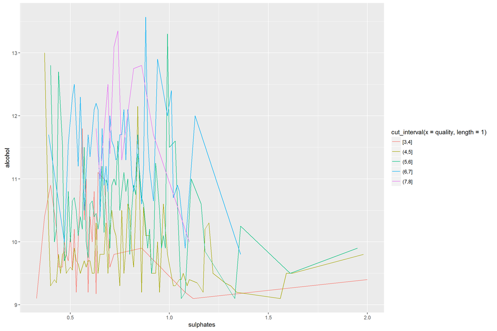

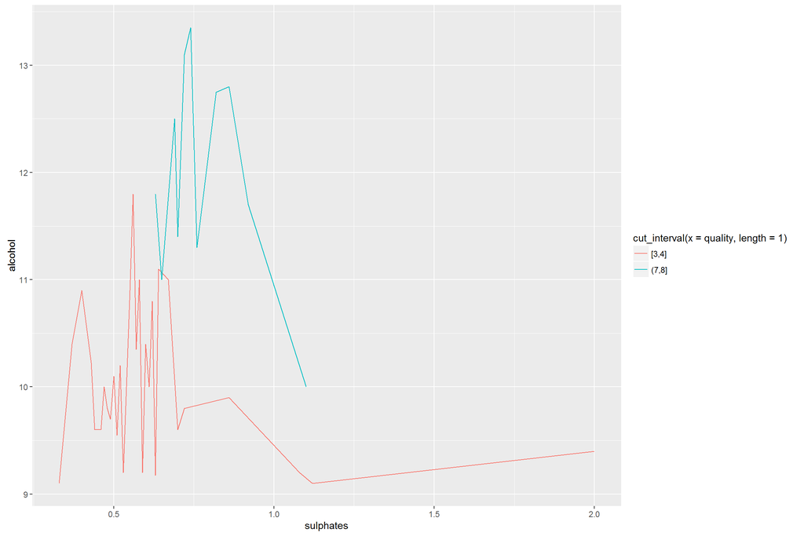

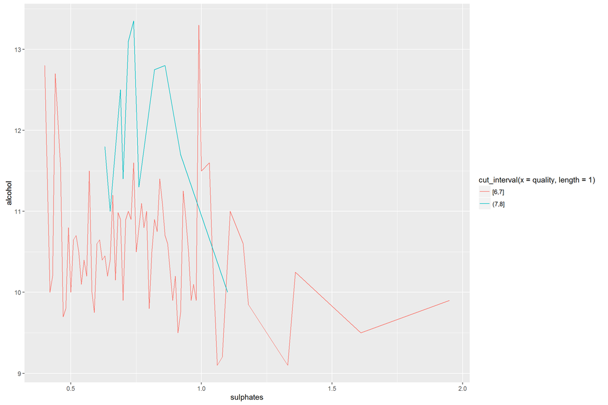

As expected with alcohol, the higher the alcohol for the same amount of sulfate the quality seems to be higher.

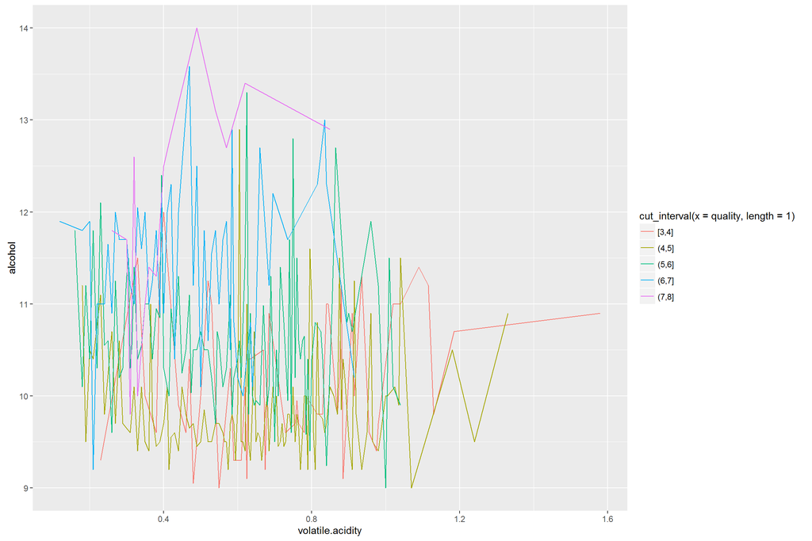

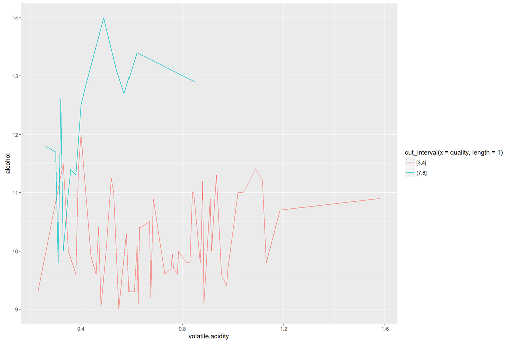

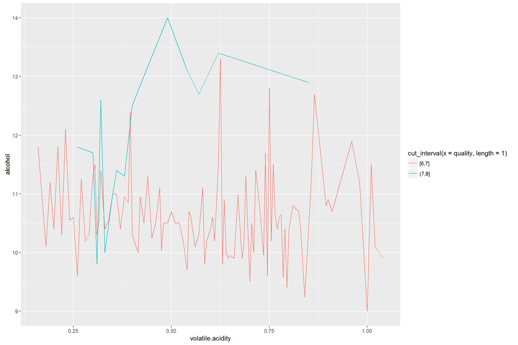

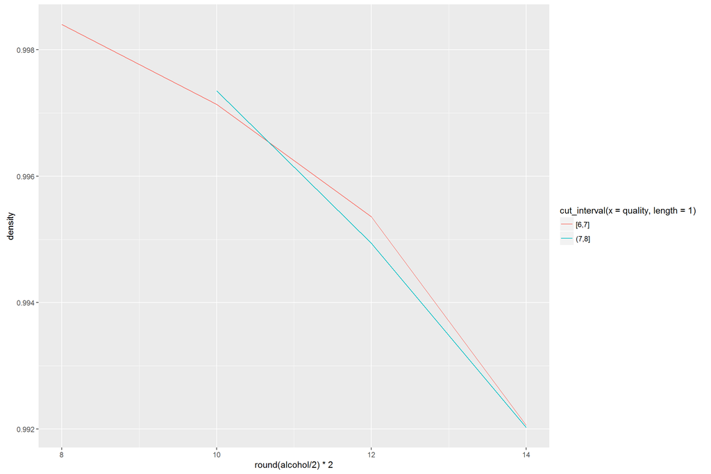

The general trend seem to be for wines with higher volatile.acidity seem to have lower quality. this corresponds with the corrolation results. we can see for higer qualities higher alcohol seem to be compensating for higher volatile.acidity.

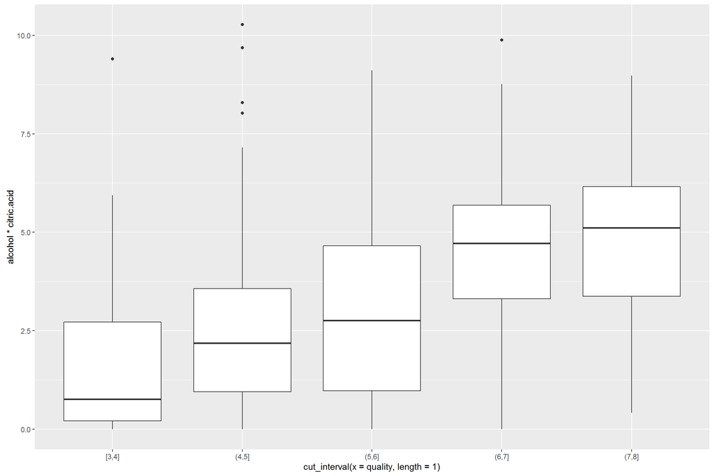

```
## wines$quality: 3
##    Min. 1st Qu.  Median    Mean 3rd Qu.    Max.
## 0.00000 0.04975 0.35250 1.56300 3.21400 5.94000
## --------------------------------------------------------
## wines$quality: 4
##    Min. 1st Qu.  Median    Mean 3rd Qu.    Max.
##   0.000   0.270   0.882   1.757   2.700   9.400
## --------------------------------------------------------
## wines$quality: 5
##    Min. 1st Qu.  Median    Mean 3rd Qu.    Max.
##   0.000   0.950   2.185   2.412   3.572  10.270
## --------------------------------------------------------
## wines$quality: 6
##    Min. 1st Qu.  Median    Mean 3rd Qu.    Max.
##   0.000   0.972   2.764   2.923   4.654   9.112
## --------------------------------------------------------
## wines$quality: 7
##    Min. 1st Qu.  Median    Mean 3rd Qu.    Max.
##   0.000   3.310   4.720   4.288   5.685   9.880
## --------------------------------------------------------
## wines$quality: 8
##    Min. 1st Qu.  Median    Mean 3rd Qu.    Max.
##   0.420   3.375   5.116   4.624   6.160   8.978
```

the product of the two positively corrolated features seem to demonstrate their affect in quality more clearly.

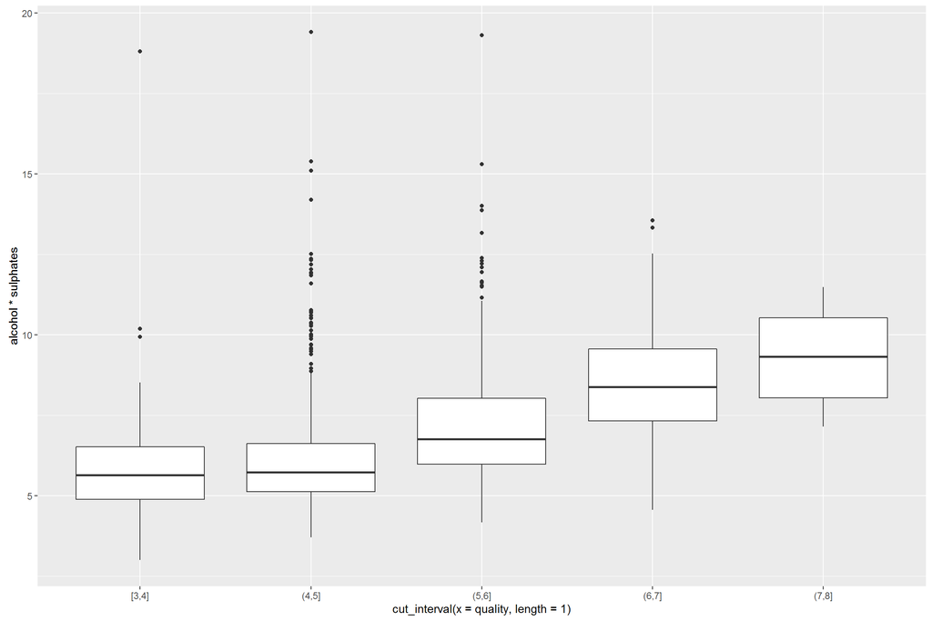

```
## wines$quality: 3
##    Min. 1st Qu.  Median    Mean 3rd Qu.    Max.
##   4.360   5.171   5.320   5.637   5.681   8.514
## --------------------------------------------------------
## wines$quality: 4
##    Min. 1st Qu.  Median    Mean 3rd Qu.    Max.
##   3.003   4.753   5.871   6.092   6.612  18.800
## --------------------------------------------------------
## wines$quality: 5
##    Min. 1st Qu.  Median    Mean 3rd Qu.    Max.
##   3.705   5.130   5.723   6.145   6.615  19.400
## --------------------------------------------------------
## wines$quality: 6
##    Min. 1st Qu.  Median    Mean 3rd Qu.    Max.
##   4.171   5.985   6.763   7.171   8.033  19.300
## --------------------------------------------------------
## wines$quality: 7
##    Min. 1st Qu.  Median    Mean 3rd Qu.    Max.
##   4.563   7.326   8.378   8.493   9.564  13.560
## --------------------------------------------------------
## wines$quality: 8
##    Min. 1st Qu.  Median    Mean 3rd Qu.    Max.
##   7.150   8.045   9.322   9.257  10.520  11.480
```

Corrolation appears here as well.

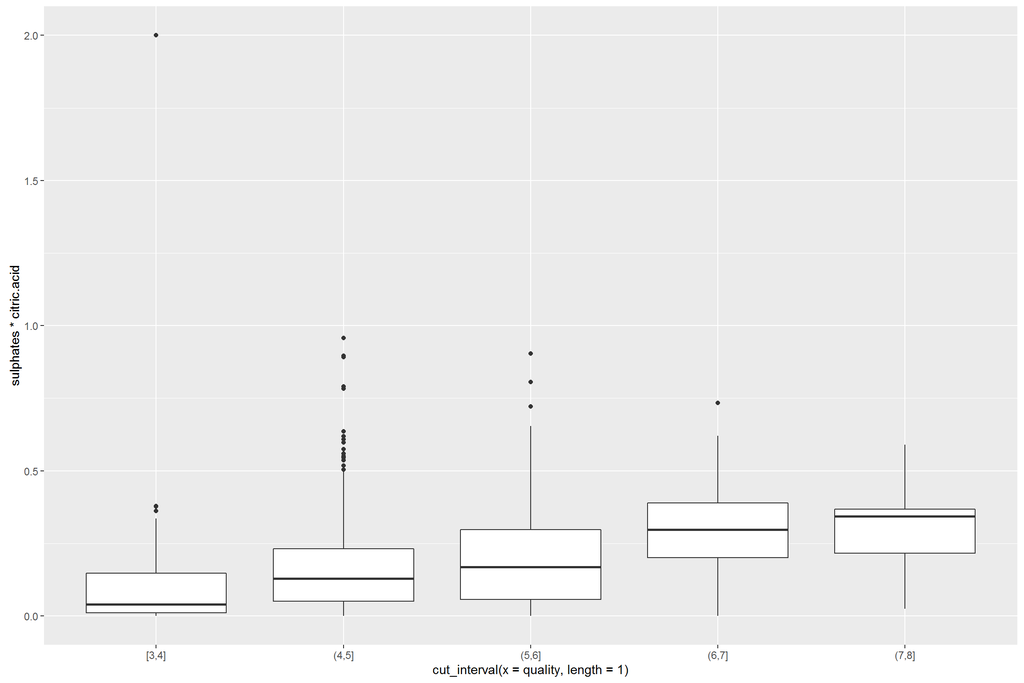

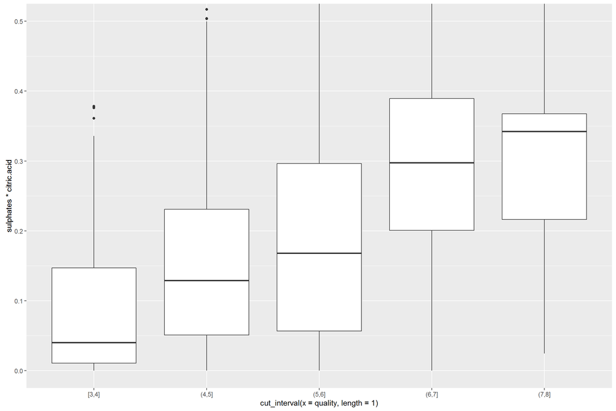

```
## wines$quality: 3
##    Min. 1st Qu.  Median    Mean 3rd Qu.    Max.
## 0.00000 0.00245 0.01930 0.11220 0.23840 0.37620
## --------------------------------------------------------
## wines$quality: 4
##    Min. 1st Qu.  Median    Mean 3rd Qu.    Max.
##  0.0000  0.0144  0.0456  0.1290  0.1408  2.0000
## --------------------------------------------------------
## wines$quality: 5
##    Min. 1st Qu.  Median    Mean 3rd Qu.    Max.
##  0.0000  0.0510  0.1292  0.1602  0.2310  0.9576
## --------------------------------------------------------
## wines$quality: 6
##    Min. 1st Qu.  Median    Mean 3rd Qu.    Max.
##  0.0000  0.0567  0.1680  0.1925  0.2965  0.9044
## --------------------------------------------------------
## wines$quality: 7
##    Min. 1st Qu.  Median    Mean 3rd Qu.    Max.
##  0.0000  0.2008  0.2976  0.2837  0.3893  0.7344
## --------------------------------------------------------
## wines$quality: 8
##    Min. 1st Qu.  Median    Mean 3rd Qu.    Max.
##  0.0246  0.2164  0.3424  0.2966  0.3675  0.5904
```

the difference between the median of product of sulphates and citric.acid at quality 3 and 8 seem to be manyfold.

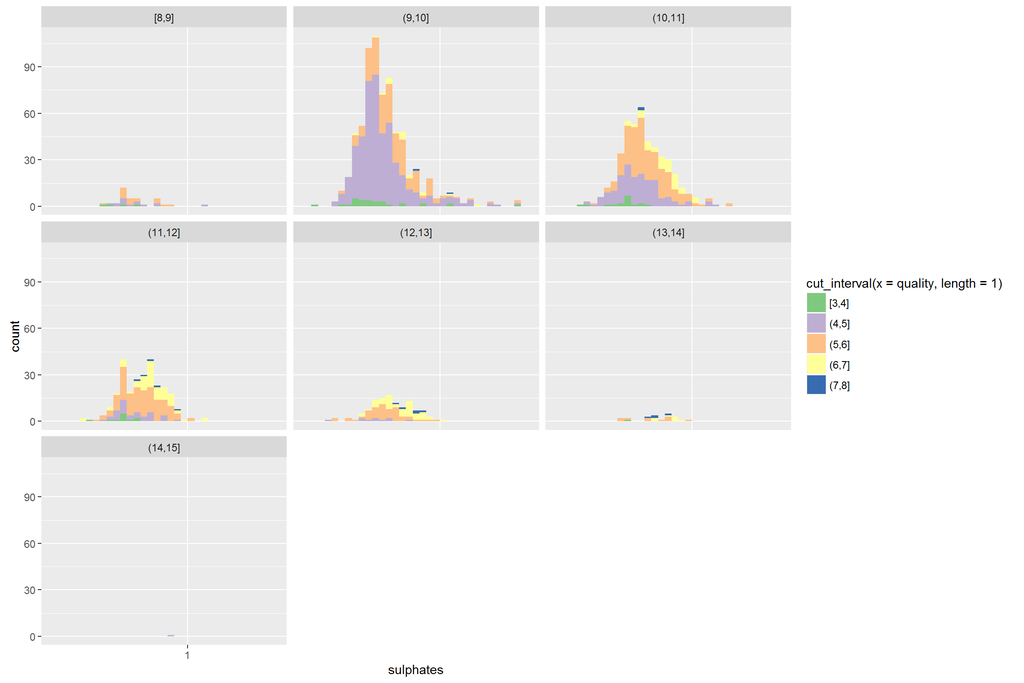

as I expected, higher quality wines tend to have higher alcohol, which overshadows the affect of higher sulphates which is very weak.

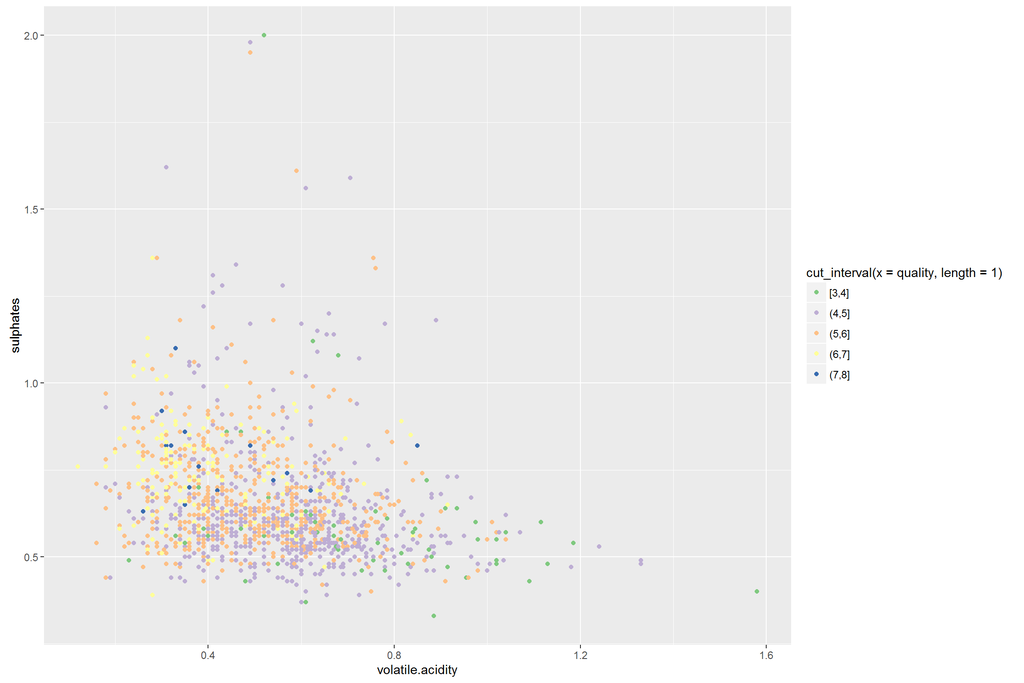

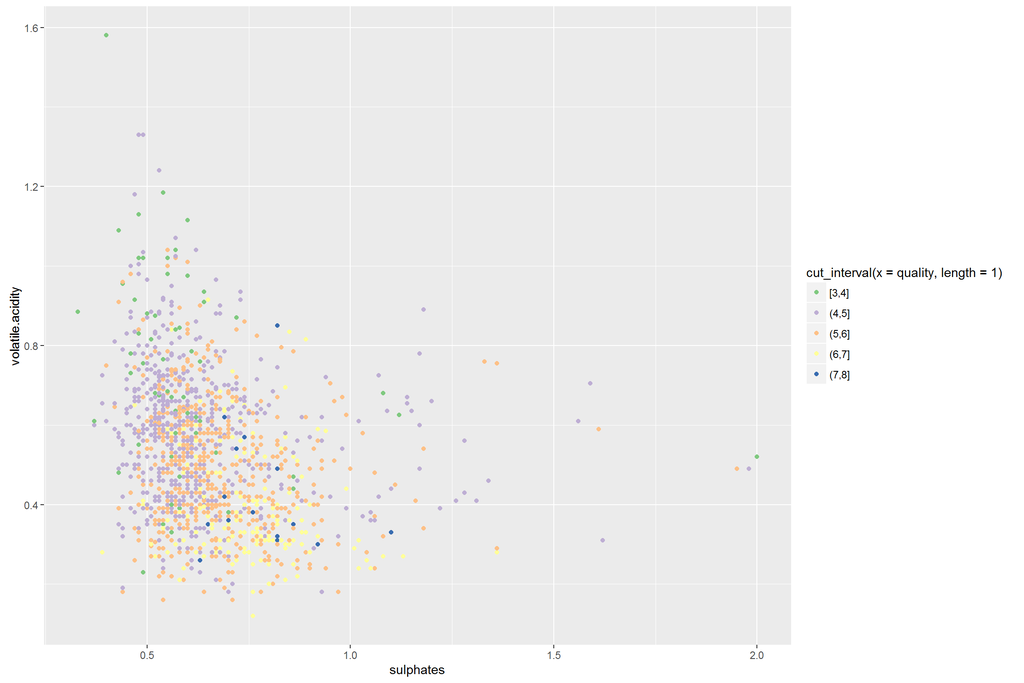

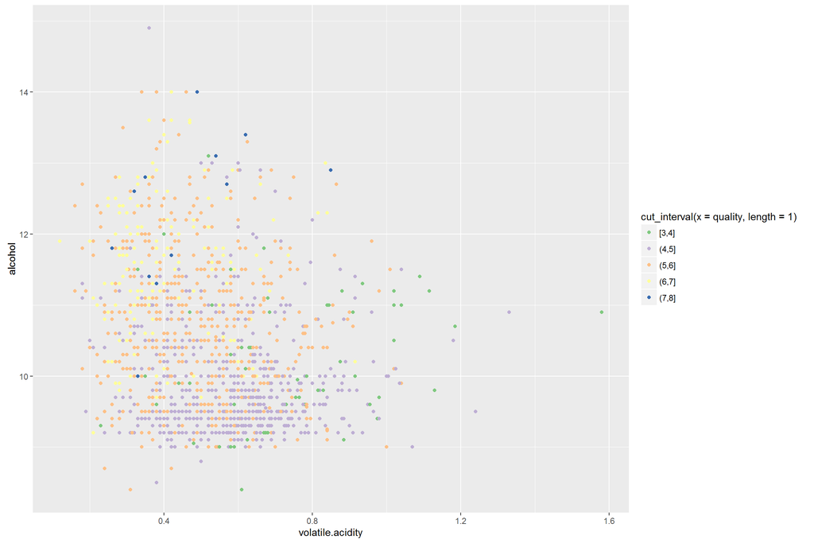

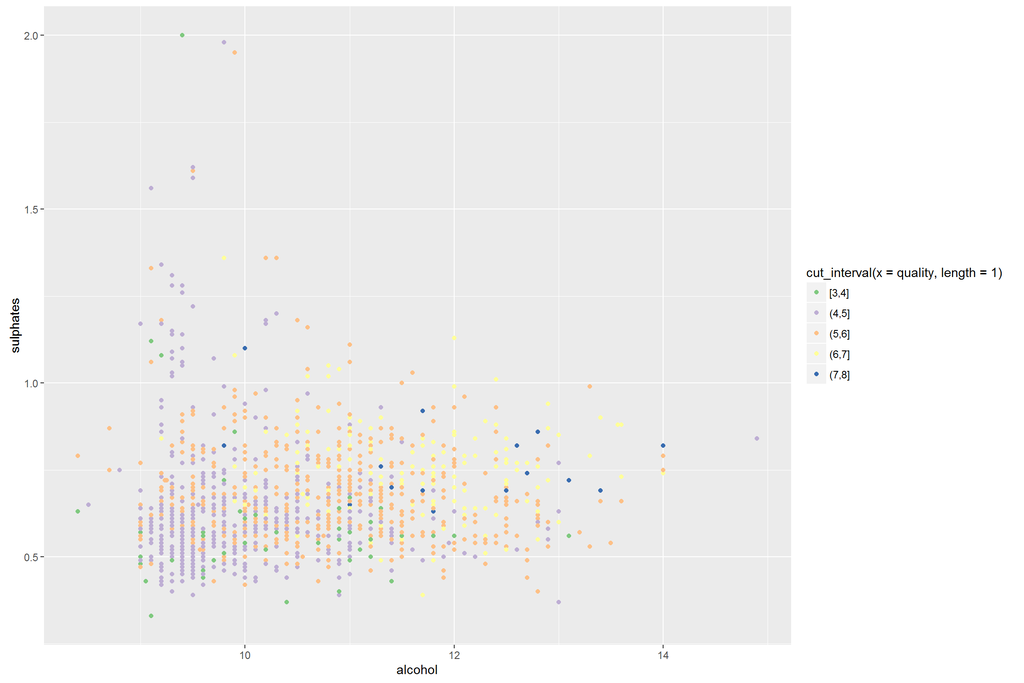

general trend seem to be for higher sulphates, lower volatile.acidity and higher alcohol to have higher quality.

```
##
## Calls:
## m4: lm(formula = quality ~ alcohol, data = wines)
## m5: lm(formula = quality ~ alcohol + sulphates, data = wines)
## m6: lm(formula = quality ~ alcohol + sulphates + citric.acid, data = wines)
## m7: lm(formula = quality ~ alcohol + sulphates + citric.acid + fixed.acidity,
##     data = wines)
## m8: lm(formula = quality ~ alcohol + sulphates + citric.acid + fixed.acidity +
##     density, data = wines)
## m9: lm(formula = quality ~ alcohol + sulphates + citric.acid + fixed.acidity +
##     density + volatile.acidity, data = wines)
## m10: lm(formula = quality ~ alcohol + sulphates + citric.acid + fixed.acidity +
##     density + volatile.acidity + chlorides, data = wines)
## m11: lm(formula = quality ~ alcohol + sulphates + citric.acid + fixed.acidity +
##     density + volatile.acidity + chlorides + residual.sugar,
##     data = wines)
## m12: lm(formula = quality ~ alcohol + sulphates + citric.acid + fixed.acidity +
##     density + volatile.acidity + chlorides + residual.sugar +
##     total.sulfur.dioxide, data = wines)
## m13: lm(formula = quality ~ alcohol + sulphates + citric.acid + fixed.acidity +
##     density + volatile.acidity + chlorides + residual.sugar +
##     total.sulfur.dioxide + pH, data = wines)
##
## ============================================================================================================================================
##                            m4         m5         m6         m7          m8          m9         m10         m11         m12         m13
## --------------------------------------------------------------------------------------------------------------------------------------------
##   (Intercept)            1.875***   1.375***   1.434***   1.138***   62.356***   30.401*     31.514*     42.871*     47.404**    25.493
##                         (0.175)    (0.177)    (0.176)    (0.214)    (15.472)    (15.163)    (15.111)    (17.775)    (17.729)    (21.142)
##   alcohol                0.361***   0.346***   0.338***   0.346***    0.296***    0.298***    0.281***    0.271***    0.249***    0.275***
##                         (0.017)    (0.016)    (0.016)    (0.016)     (0.021)     (0.020)     (0.020)     (0.022)     (0.023)     (0.026)
##   sulphates                         0.994***   0.814***   0.821***    0.881***    0.732***    0.885***    0.905***    0.955***    0.929***
##                                    (0.102)    (0.107)    (0.106)     (0.107)     (0.104)     (0.112)     (0.113)     (0.114)     (0.114)
##   citric.acid                                  0.513***   0.312*      0.278*     -0.460***   -0.325*     -0.344*     -0.215      -0.231
##                                               (0.093)    (0.125)     (0.125)     (0.137)     (0.141)     (0.142)     (0.145)     (0.145)
##   fixed.acidity                                           0.033*      0.076***    0.077***    0.070***    0.078***    0.066***    0.031
##                                                          (0.013)     (0.017)     (0.017)     (0.017)     (0.018)     (0.018)     (0.026)
##   density                                                           -61.296***  -28.268     -29.221     -40.621*    -44.859*    -21.594
##                                                                     (15.490)    (15.198)    (15.145)    (17.822)    (17.772)    (21.575)
##   volatile.acidity                                                               -1.302***   -1.195***   -1.192***   -1.125***   -1.124***
##                                                                                  (0.116)     (0.119)     (0.119)     (0.120)     (0.120)
```

[output cut: 20 more lines]

seems to be a poor model. the maximum R-squared reached, including many features, is 0.4.

# Multivariate Analysis:

## Talk about some of the relationships you observed in this part of the investigation. Were there features that strengthened each other in terms of looking at your feature(s) of interest?

there are obvious corrolations between pH and fixed.acidity and free.sulfur.dioxide and free sulfur.dioxide. although, there is a week corrolation between quality and sulphates, citric.acid and chlorides, there are many data points/samples that do not seem to have any corrolation between the features. for instance there are a lot of fluctuations in the line plot for sulfates vs. alcohol for different qualities.

## Were there any interesting or surprising interactions between features?

there were a couple of them namely the relationship between alcohol and density. wines with higher alcohol seem to have on average lower density and there is a very week negative corrolation between density and quality.

## OPTIONAL: Did you create any models with your dataset? Discuss the strengths and limitations of your model.

I created a linear model using quality and alcohol. alcohol only described 0.2 of variance in quality. by adding different feature, the R-squared was raised to 0.4.

# Final Plots and Summary

## Plot One

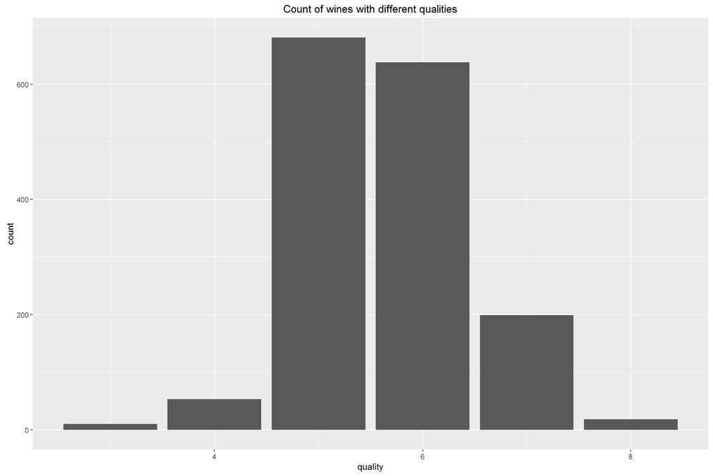

```
##
##   3   4   5   6   7   8
##  10  53 681 638 199  18
```

## description 1:

The majority of samples are of quality 5 or 6 (82%), with median at 6 and mean at 5.636.It’s still a normal distribution, but with having much fewer samples for qualities 3 and 8, it will be harder to build a model.

## Plot two:

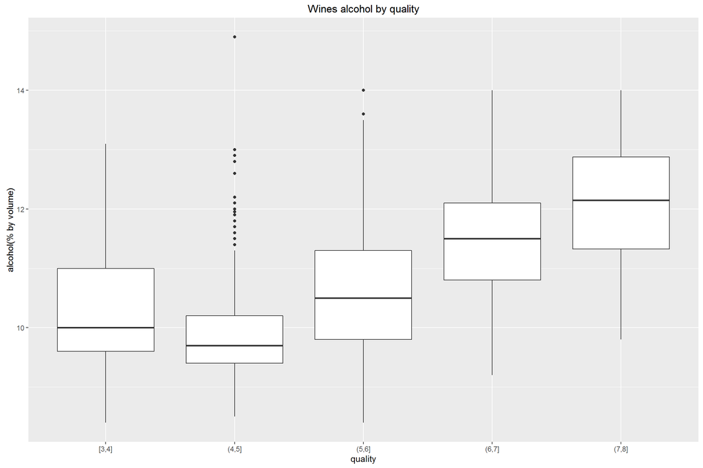

## Plot three:

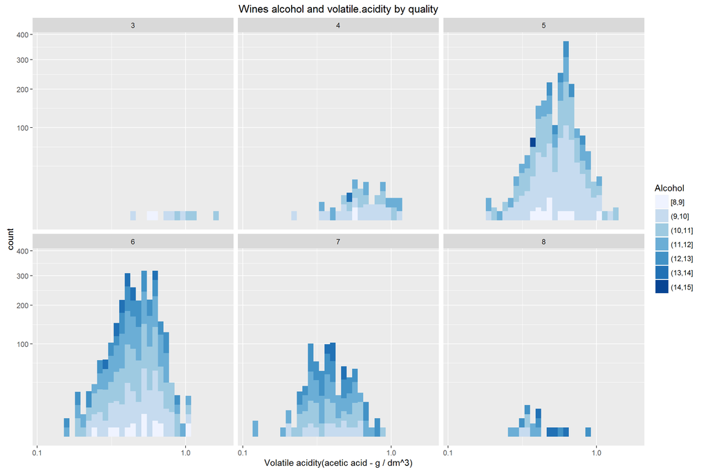

## Description 3:

Facet wrapping wines by Quality and filling with alcohol and using volatile.acidity as x axis, shows that for higher qualities there are more of wines with higher alcohol and also counts for wines with higher alcohol are generally higher. ALso it shows that wines with higher quality have lower volatile acidity. Among wines with quality of 3 there is no sample with alcohol higher that 11.

# Reflection:

The red wine dataset contains 1599 observations with 13 features. Except One feature, quality, the rest are measurable, chemical specifications of wine. quality is an abstract and non-measurable feature that is sensory and based on experts opinions. I started by examining each feature and looking at their distribution, which for most part was normal. Then tried to find the relation between different features and specially all features with the outcome feature, quality. According to corrolation figures obtained by function cor(wines), the features that are corrolated with quality are alcohol, volatile.acidity, sulphates and citric.acid. Most of whom are weekly corrolated. Further observations more or less confirmed the relations. There are a few features that are related by nature and definition, such as pH and citric.acid, as pH is the measurement of acidity. I tried to fit a linear model to the data. The best outcome was 40% of variance of quality being accounted for, through a model, using most of variables, Although it is not a very high rate, but given the sensory nature of outcome variable, quality, it is a good starting point to build more accurate models. Building non-linear models that can for instance include different orders of polynomials and collecting more data and or looking into more complete datasets are two of the options. Using a classification model instead of regression might be a good choice, as predicting wines quality in this context seems to be more of a classification problem.